# Risk Factor Analysis

## Outcome Variable

**Outcome Variable:** pers_wast

## Predictor Variables

**Intervention Variable:** mhtcm

**Adjustment Set:**

unadjusted

## Stratifying Variables

The analysis was stratified on these variable(s):

- agecat
- studyid
- country

## Data Summary

| agecat | studyid | country | mhtcm | pers_wast | n_cell | n |
| --- | --- | --- | --- | --- | --- | --- |
| 0-24 months | COHORTS | GUATEMALA | >=155 cm | 0 | 126 | 1026 |
| 0-24 months | COHORTS | GUATEMALA | >=155 cm | 1 | 6 | 1026 |
| 0-24 months | COHORTS | GUATEMALA | <151 cm | 0 | 653 | 1026 |
| 0-24 months | COHORTS | GUATEMALA | <151 cm | 1 | 23 | 1026 |
| 0-24 months | COHORTS | GUATEMALA | [151-155) cm | 0 | 212 | 1026 |
| 0-24 months | COHORTS | GUATEMALA | [151-155) cm | 1 | 6 | 1026 |
| 0-24 months | COHORTS | INDIA | >=155 cm | 0 | 439 | 1635 |
| 0-24 months | COHORTS | INDIA | >=155 cm | 1 | 42 | 1635 |
| 0-24 months | COHORTS | INDIA | <151 cm | 0 | 654 | 1635 |
| 0-24 months | COHORTS | INDIA | <151 cm | 1 | 67 | 1635 |
| 0-24 months | COHORTS | INDIA | [151-155) cm | 0 | 401 | 1635 |
| 0-24 months | COHORTS | INDIA | [151-155) cm | 1 | 32 | 1635 |
| 0-24 months | COHORTS | PHILIPPINES | >=155 cm | 0 | 557 | 2811 |
| 0-24 months | COHORTS | PHILIPPINES | >=155 cm | 1 | 26 | 2811 |
| 0-24 months | COHORTS | PHILIPPINES | <151 cm | 0 | 1345 | 2811 |
| 0-24 months | COHORTS | PHILIPPINES | <151 cm | 1 | 77 | 2811 |
| 0-24 months | COHORTS | PHILIPPINES | [151-155) cm | 0 | 765 | 2811 |
| 0-24 months | COHORTS | PHILIPPINES | [151-155) cm | 1 | 41 | 2811 |
| 0-24 months | Guatemala BSC | GUATEMALA | >=155 cm | 0 | 35 | 214 |
| 0-24 months | Guatemala BSC | GUATEMALA | >=155 cm | 1 | 0 | 214 |
| 0-24 months | Guatemala BSC | GUATEMALA | <151 cm | 0 | 124 | 214 |
| 0-24 months | Guatemala BSC | GUATEMALA | <151 cm | 1 | 3 | 214 |
| 0-24 months | Guatemala BSC | GUATEMALA | [151-155) cm | 0 | 51 | 214 |
| 0-24 months | Guatemala BSC | GUATEMALA | [151-155) cm | 1 | 1 | 214 |
| 0-24 months | iLiNS-Zinc | BURKINA FASO | >=155 cm | 0 | 1323 | 1645 |
| 0-24 months | iLiNS-Zinc | BURKINA FASO | >=155 cm | 1 | 164 | 1645 |
| 0-24 months | iLiNS-Zinc | BURKINA FASO | <151 cm | 0 | 34 | 1645 |
| 0-24 months | iLiNS-Zinc | BURKINA FASO | <151 cm | 1 | 10 | 1645 |
| 0-24 months | iLiNS-Zinc | BURKINA FASO | [151-155) cm | 0 | 95 | 1645 |
| 0-24 months | iLiNS-Zinc | BURKINA FASO | [151-155) cm | 1 | 19 | 1645 |

[output cut: 324 more lines]

The following strata were considered:

- agecat: 0-24 months, studyid: COHORTS, country: GUATEMALA
- agecat: 0-24 months, studyid: COHORTS, country: INDIA
- agecat: 0-24 months, studyid: COHORTS, country: PHILIPPINES
- agecat: 0-24 months, studyid: Guatemala BSC, country: GUATEMALA
- agecat: 0-24 months, studyid: iLiNS-Zinc, country: BURKINA FASO
- agecat: 0-24 months, studyid: Keneba, country: GAMBIA
- agecat: 0-24 months, studyid: LCNI-5, country: MALAWI
- agecat: 0-24 months, studyid: MAL-ED, country: BANGLADESH
- agecat: 0-24 months, studyid: MAL-ED, country: BRAZIL
- agecat: 0-24 months, studyid: MAL-ED, country: INDIA
- agecat: 0-24 months, studyid: MAL-ED, country: NEPAL
- agecat: 0-24 months, studyid: MAL-ED, country: PERU
- agecat: 0-24 months, studyid: MAL-ED, country: SOUTH AFRICA
- agecat: 0-24 months, studyid: MAL-ED, country: TANZANIA, UNITED REPUBLIC OF
- agecat: 0-24 months, studyid: NIH-Birth, country: BANGLADESH
- agecat: 0-24 months, studyid: NIH-Crypto, country: BANGLADESH
- agecat: 0-24 months, studyid: PROBIT, country: BELARUS
- agecat: 0-24 months, studyid: PROVIDE, country: BANGLADESH
- agecat: 0-24 months, studyid: SAS-CompFeed, country: INDIA
- agecat: 0-24 months, studyid: SAS-FoodSuppl, country: INDIA
- agecat: 0-24 months, studyid: TanzaniaChild2, country: TANZANIA, UNITED REPUBLIC OF
- agecat: 0-24 months, studyid: ZVITAMBO, country: ZIMBABWE
- agecat: 0-6 months, studyid: COHORTS, country: PHILIPPINES
- agecat: 0-6 months, studyid: Keneba, country: GAMBIA
- agecat: 0-6 months, studyid: MAL-ED, country: BANGLADESH
- agecat: 0-6 months, studyid: MAL-ED, country: BRAZIL
- agecat: 0-6 months, studyid: MAL-ED, country: INDIA
- agecat: 0-6 months, studyid: MAL-ED, country: NEPAL
- agecat: 0-6 months, studyid: MAL-ED, country: PERU
- agecat: 0-6 months, studyid: MAL-ED, country: SOUTH AFRICA
- agecat: 0-6 months, studyid: MAL-ED, country: TANZANIA, UNITED REPUBLIC OF
- agecat: 0-6 months, studyid: NIH-Birth, country: BANGLADESH
- agecat: 0-6 months, studyid: NIH-Crypto, country: BANGLADESH
- agecat: 0-6 months, studyid: PROBIT, country: BELARUS
- agecat: 0-6 months, studyid: PROVIDE, country: BANGLADESH
- agecat: 0-6 months, studyid: TanzaniaChild2, country: TANZANIA, UNITED REPUBLIC OF
- agecat: 0-6 months, studyid: ZVITAMBO, country: ZIMBABWE
- agecat: 6-24 months, studyid: COHORTS, country: GUATEMALA
- agecat: 6-24 months, studyid: COHORTS, country: INDIA
- agecat: 6-24 months, studyid: COHORTS, country: PHILIPPINES
- agecat: 6-24 months, studyid: Guatemala BSC, country: GUATEMALA
- agecat: 6-24 months, studyid: iLiNS-Zinc, country: BURKINA FASO
- agecat: 6-24 months, studyid: Keneba, country: GAMBIA
- agecat: 6-24 months, studyid: LCNI-5, country: MALAWI
- agecat: 6-24 months, studyid: MAL-ED, country: BANGLADESH
- agecat: 6-24 months, studyid: MAL-ED, country: BRAZIL
- agecat: 6-24 months, studyid: MAL-ED, country: INDIA
- agecat: 6-24 months, studyid: MAL-ED, country: NEPAL
- agecat: 6-24 months, studyid: MAL-ED, country: PERU
- agecat: 6-24 months, studyid: MAL-ED, country: SOUTH AFRICA
- agecat: 6-24 months, studyid: MAL-ED, country: TANZANIA, UNITED REPUBLIC OF
- agecat: 6-24 months, studyid: NIH-Birth, country: BANGLADESH
- agecat: 6-24 months, studyid: NIH-Crypto, country: BANGLADESH
- agecat: 6-24 months, studyid: PROBIT, country: BELARUS
- agecat: 6-24 months, studyid: PROVIDE, country: BANGLADESH
- agecat: 6-24 months, studyid: SAS-CompFeed, country: INDIA
- agecat: 6-24 months, studyid: SAS-FoodSuppl, country: INDIA
- agecat: 6-24 months, studyid: TanzaniaChild2, country: TANZANIA, UNITED REPUBLIC OF
- agecat: 6-24 months, studyid: ZVITAMBO, country: ZIMBABWE

### Dropped Strata

Some strata were dropped due to rare outcomes:

- agecat: 0-24 months, studyid: Guatemala BSC, country: GUATEMALA
- agecat: 0-24 months, studyid: LCNI-5, country: MALAWI
- agecat: 0-24 months, studyid: MAL-ED, country: BANGLADESH
- agecat: 0-24 months, studyid: MAL-ED, country: BRAZIL
- agecat: 0-24 months, studyid: MAL-ED, country: INDIA
- agecat: 0-24 months, studyid: MAL-ED, country: NEPAL
- agecat: 0-24 months, studyid: MAL-ED, country: PERU
- agecat: 0-24 months, studyid: MAL-ED, country: SOUTH AFRICA
- agecat: 0-24 months, studyid: MAL-ED, country: TANZANIA, UNITED REPUBLIC OF
- agecat: 0-24 months, studyid: NIH-Crypto, country: BANGLADESH
- agecat: 0-24 months, studyid: PROBIT, country: BELARUS
- agecat: 0-6 months, studyid: MAL-ED, country: BANGLADESH
- agecat: 0-6 months, studyid: MAL-ED, country: BRAZIL
- agecat: 0-6 months, studyid: MAL-ED, country: INDIA
- agecat: 0-6 months, studyid: MAL-ED, country: NEPAL
- agecat: 0-6 months, studyid: MAL-ED, country: PERU
- agecat: 0-6 months, studyid: MAL-ED, country: SOUTH AFRICA
- agecat: 0-6 months, studyid: MAL-ED, country: TANZANIA, UNITED REPUBLIC OF
- agecat: 0-6 months, studyid: NIH-Birth, country: BANGLADESH
- agecat: 0-6 months, studyid: NIH-Crypto, country: BANGLADESH
- agecat: 0-6 months, studyid: PROVIDE, country: BANGLADESH
- agecat: 0-6 months, studyid: ZVITAMBO, country: ZIMBABWE
- agecat: 6-24 months, studyid: Guatemala BSC, country: GUATEMALA
- agecat: 6-24 months, studyid: LCNI-5, country: MALAWI
- agecat: 6-24 months, studyid: MAL-ED, country: BANGLADESH
- agecat: 6-24 months, studyid: MAL-ED, country: BRAZIL
- agecat: 6-24 months, studyid: MAL-ED, country: INDIA
- agecat: 6-24 months, studyid: MAL-ED, country: NEPAL
- agecat: 6-24 months, studyid: MAL-ED, country: PERU
- agecat: 6-24 months, studyid: MAL-ED, country: SOUTH AFRICA
- agecat: 6-24 months, studyid: MAL-ED, country: TANZANIA, UNITED REPUBLIC OF
- agecat: 6-24 months, studyid: NIH-Crypto, country: BANGLADESH
- agecat: 6-24 months, studyid: PROBIT, country: BELARUS

## Methods Detail

We’re interested in the causal parameters $E[Y_a]$ for all values of $a \in \mathcal{A}$. These parameters represent the mean outcome if, possibly contrary to fact, we intervened to set all units to have $A=a$. Under the randomization and positivity assumptions, these are identified by the statistical parameters $\psi_a=E_W[E_{Y|A,W}(Y|A=a,W)]$. In addition, we’re interested in the mean of $Y$, $E[Y]$ under no intervention (the observed mean). We will estimate these parameters by using SuperLearner to fit the relevant likelihood factors – $E_{Y|A,W}(Y|A=a,W)$ and $p(A=a|W)$, and then updating our likelihood fit using a joint TMLE.

For unadjusted analyses ($W=\{\}$), initial likelihoods were estimated using Lrnr_glm to estimate the simple $E(Y|A)$ and Lrnr_mean to estimate $p(A)$. For adjusted analyses, a small library containing Lrnr_glmnet, Lrnr_xgboost, and Lrnr_mean was used.

Having estimated these parameters, we will then use the delta method to estimate relative risks and attributable risks relative to a prespecified baseline level of $A$.

# Results Detail

## Results Plots

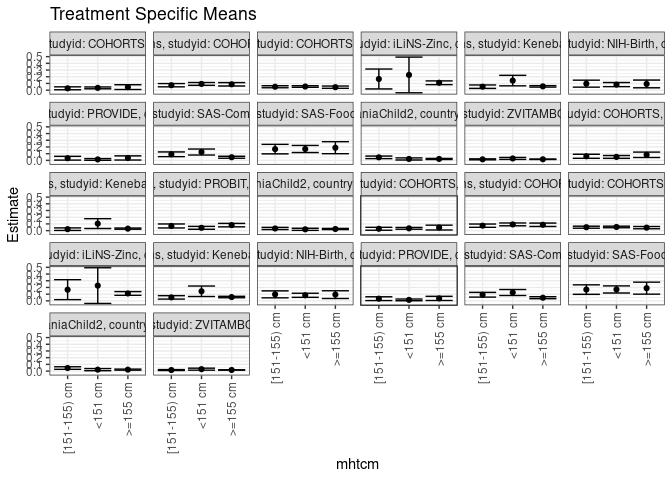

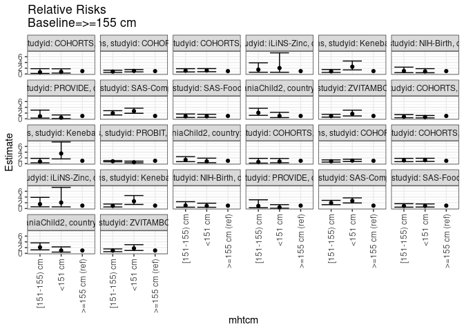

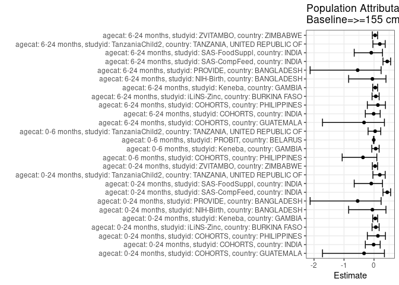

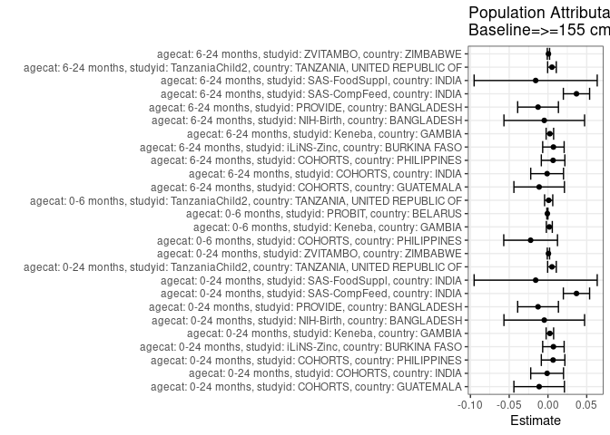

## Results Table

### Parameter: TSM

| agecat | studyid | country | intervention_level | baseline_level | estimate | ci_lower | ci_upper |
| --- | --- | --- | --- | --- | --- | --- | --- |
| 0-24 months | COHORTS | GUATEMALA | >=155 cm | NA | 0.0454545 | 0.0099029 | 0.0810062 |
| 0-24 months | COHORTS | GUATEMALA | <151 cm | NA | 0.0340237 | 0.0203508 | 0.0476966 |
| 0-24 months | COHORTS | GUATEMALA | [151-155) cm | NA | 0.0275229 | 0.0057950 | 0.0492509 |
| 0-24 months | COHORTS | INDIA | >=155 cm | NA | 0.0873181 | 0.0620821 | 0.1125541 |
| 0-24 months | COHORTS | INDIA | <151 cm | NA | 0.0929265 | 0.0717280 | 0.1141250 |
| 0-24 months | COHORTS | INDIA | [151-155) cm | NA | 0.0739030 | 0.0492542 | 0.0985518 |
| 0-24 months | COHORTS | PHILIPPINES | >=155 cm | NA | 0.0445969 | 0.0278383 | 0.0613555 |
| 0-24 months | COHORTS | PHILIPPINES | <151 cm | NA | 0.0541491 | 0.0423843 | 0.0659138 |
| 0-24 months | COHORTS | PHILIPPINES | [151-155) cm | NA | 0.0508685 | 0.0356964 | 0.0660406 |
| 0-24 months | iLiNS-Zinc | BURKINA FASO | >=155 cm | NA | 0.1102892 | 0.0825662 | 0.1380122 |
| 0-24 months | iLiNS-Zinc | BURKINA FASO | <151 cm | NA | 0.2272727 | -0.0388076 | 0.4933530 |
| 0-24 months | iLiNS-Zinc | BURKINA FASO | [151-155) cm | NA | 0.1666667 | 0.0180642 | 0.3152691 |
| 0-24 months | Keneba | GAMBIA | >=155 cm | NA | 0.0564877 | 0.0457844 | 0.0671910 |
| 0-24 months | Keneba | GAMBIA | <151 cm | NA | 0.1428571 | 0.0646798 | 0.2210345 |
| 0-24 months | Keneba | GAMBIA | [151-155) cm | NA | 0.0519031 | 0.0263218 | 0.0774844 |
| 0-24 months | NIH-Birth | BANGLADESH | >=155 cm | NA | 0.0927835 | 0.0349925 | 0.1505745 |
| 0-24 months | NIH-Birth | BANGLADESH | <151 cm | NA | 0.0830671 | 0.0524639 | 0.1136702 |
| 0-24 months | NIH-Birth | BANGLADESH | [151-155) cm | NA | 0.0967742 | 0.0446880 | 0.1488603 |
| 0-24 months | PROVIDE | BANGLADESH | >=155 cm | NA | 0.0362319 | 0.0050301 | 0.0674337 |
| 0-24 months | PROVIDE | BANGLADESH | <151 cm | NA | 0.0143678 | 0.0018551 | 0.0268805 |
| 0-24 months | PROVIDE | BANGLADESH | [151-155) cm | NA | 0.0324675 | 0.0044529 | 0.0604822 |
| 0-24 months | SAS-CompFeed | INDIA | >=155 cm | NA | 0.0467290 | 0.0320565 | 0.0614015 |
| 0-24 months | SAS-CompFeed | INDIA | <151 cm | NA | 0.1247059 | 0.0798920 | 0.1695198 |
| 0-24 months | SAS-CompFeed | INDIA | [151-155) cm | NA | 0.0909091 | 0.0558662 | 0.1259520 |
| 0-24 months | SAS-FoodSuppl | INDIA | >=155 cm | NA | 0.1891892 | 0.0998340 | 0.2785444 |
| 0-24 months | SAS-FoodSuppl | INDIA | <151 cm | NA | 0.1701031 | 0.1171617 | 0.2230445 |
| 0-24 months | SAS-FoodSuppl | INDIA | [151-155) cm | NA | 0.1682243 | 0.0972529 | 0.2391957 |
| 0-24 months | TanzaniaChild2 | TANZANIA, UNITED REPUBLIC OF | >=155 cm | NA | 0.0215613 | 0.0137972 | 0.0293255 |
| 0-24 months | TanzaniaChild2 | TANZANIA, UNITED REPUBLIC OF | <151 cm | NA | 0.0214724 | 0.0057337 | 0.0372111 |
| 0-24 months | TanzaniaChild2 | TANZANIA, UNITED REPUBLIC OF | [151-155) cm | NA | 0.0454545 | 0.0264562 | 0.0644529 |
| 0-24 months | ZVITAMBO | ZIMBABWE | >=155 cm | NA | 0.0165022 | 0.0134011 | 0.0196032 |
| 0-24 months | ZVITAMBO | ZIMBABWE | <151 cm | NA | 0.0286885 | 0.0138771 | 0.0435000 |
| 0-24 months | ZVITAMBO | ZIMBABWE | [151-155) cm | NA | 0.0157546 | 0.0087262 | 0.0227830 |
| 0-6 months | COHORTS | PHILIPPINES | >=155 cm | NA | 0.0833333 | 0.0429333 | 0.1237334 |
| 0-6 months | COHORTS | PHILIPPINES | <151 cm | NA | 0.0514019 | 0.0304698 | 0.0723339 |
| 0-6 months | COHORTS | PHILIPPINES | [151-155) cm | NA | 0.0612245 | 0.0311870 | 0.0912620 |
| 0-6 months | Keneba | GAMBIA | >=155 cm | NA | 0.0295440 | 0.0211311 | 0.0379569 |
| 0-6 months | Keneba | GAMBIA | <151 cm | NA | 0.1044776 | 0.0312158 | 0.1777394 |
| 0-6 months | Keneba | GAMBIA | [151-155) cm | NA | 0.0218341 | 0.0029010 | 0.0407671 |
| 0-6 months | PROBIT | BELARUS | >=155 cm | NA | 0.0821355 | 0.0565180 | 0.1077530 |
| 0-6 months | PROBIT | BELARUS | <151 cm | NA | 0.0416667 | 0.0202046 | 0.0631287 |
| 0-6 months | PROBIT | BELARUS | [151-155) cm | NA | 0.0691489 | 0.0394049 | 0.0988930 |
| 0-6 months | TanzaniaChild2 | TANZANIA, UNITED REPUBLIC OF | >=155 cm | NA | 0.0242187 | 0.0157951 | 0.0326424 |
| 0-6 months | TanzaniaChild2 | TANZANIA, UNITED REPUBLIC OF | <151 cm | NA | 0.0194805 | 0.0040419 | 0.0349191 |
| 0-6 months | TanzaniaChild2 | TANZANIA, UNITED REPUBLIC OF | [151-155) cm | NA | 0.0317460 | 0.0153788 | 0.0481133 |
| 6-24 months | COHORTS | GUATEMALA | >=155 cm | NA | 0.0454545 | 0.0099029 | 0.0810062 |
| 6-24 months | COHORTS | GUATEMALA | <151 cm | NA | 0.0340237 | 0.0203508 | 0.0476966 |
| 6-24 months | COHORTS | GUATEMALA | [151-155) cm | NA | 0.0275229 | 0.0057950 | 0.0492509 |
| 6-24 months | COHORTS | INDIA | >=155 cm | NA | 0.0873181 | 0.0620821 | 0.1125541 |
| 6-24 months | COHORTS | INDIA | <151 cm | NA | 0.0929265 | 0.0717280 | 0.1141250 |
| 6-24 months | COHORTS | INDIA | [151-155) cm | NA | 0.0739030 | 0.0492542 | 0.0985518 |
| 6-24 months | COHORTS | PHILIPPINES | >=155 cm | NA | 0.0445969 | 0.0278383 | 0.0613555 |
| 6-24 months | COHORTS | PHILIPPINES | <151 cm | NA | 0.0541491 | 0.0423843 | 0.0659138 |
| 6-24 months | COHORTS | PHILIPPINES | [151-155) cm | NA | 0.0508685 | 0.0356964 | 0.0660406 |
| 6-24 months | iLiNS-Zinc | BURKINA FASO | >=155 cm | NA | 0.1102892 | 0.0825662 | 0.1380122 |
| 6-24 months | iLiNS-Zinc | BURKINA FASO | <151 cm | NA | 0.2272727 | -0.0388076 | 0.4933530 |
| 6-24 months | iLiNS-Zinc | BURKINA FASO | [151-155) cm | NA | 0.1666667 | 0.0180642 | 0.3152691 |
| 6-24 months | Keneba | GAMBIA | >=155 cm | NA | 0.0564877 | 0.0457844 | 0.0671910 |
| 6-24 months | Keneba | GAMBIA | <151 cm | NA | 0.1428571 | 0.0646798 | 0.2210345 |
| 6-24 months | Keneba | GAMBIA | [151-155) cm | NA | 0.0519031 | 0.0263218 | 0.0774844 |
| 6-24 months | NIH-Birth | BANGLADESH | >=155 cm | NA | 0.0927835 | 0.0349925 | 0.1505745 |
| 6-24 months | NIH-Birth | BANGLADESH | <151 cm | NA | 0.0830671 | 0.0524639 | 0.1136702 |
| 6-24 months | NIH-Birth | BANGLADESH | [151-155) cm | NA | 0.0967742 | 0.0446880 | 0.1488603 |
| 6-24 months | PROVIDE | BANGLADESH | >=155 cm | NA | 0.0362319 | 0.0050301 | 0.0674337 |
| 6-24 months | PROVIDE | BANGLADESH | <151 cm | NA | 0.0143678 | 0.0018551 | 0.0268805 |
| 6-24 months | PROVIDE | BANGLADESH | [151-155) cm | NA | 0.0324675 | 0.0044529 | 0.0604822 |
| 6-24 months | SAS-CompFeed | INDIA | >=155 cm | NA | 0.0467290 | 0.0320565 | 0.0614015 |
| 6-24 months | SAS-CompFeed | INDIA | <151 cm | NA | 0.1247059 | 0.0798920 | 0.1695198 |
| 6-24 months | SAS-CompFeed | INDIA | [151-155) cm | NA | 0.0909091 | 0.0558662 | 0.1259520 |
| 6-24 months | SAS-FoodSuppl | INDIA | >=155 cm | NA | 0.1891892 | 0.0998340 | 0.2785444 |
| 6-24 months | SAS-FoodSuppl | INDIA | <151 cm | NA | 0.1701031 | 0.1171617 | 0.2230445 |
| 6-24 months | SAS-FoodSuppl | INDIA | [151-155) cm | NA | 0.1682243 | 0.0972529 | 0.2391957 |
| 6-24 months | TanzaniaChild2 | TANZANIA, UNITED REPUBLIC OF | >=155 cm | NA | 0.0215613 | 0.0137972 | 0.0293255 |
| 6-24 months | TanzaniaChild2 | TANZANIA, UNITED REPUBLIC OF | <151 cm | NA | 0.0214724 | 0.0057337 | 0.0372111 |
| 6-24 months | TanzaniaChild2 | TANZANIA, UNITED REPUBLIC OF | [151-155) cm | NA | 0.0454545 | 0.0264562 | 0.0644529 |
| 6-24 months | ZVITAMBO | ZIMBABWE | >=155 cm | NA | 0.0165022 | 0.0134011 | 0.0196032 |
| 6-24 months | ZVITAMBO | ZIMBABWE | <151 cm | NA | 0.0286885 | 0.0138771 | 0.0435000 |
| 6-24 months | ZVITAMBO | ZIMBABWE | [151-155) cm | NA | 0.0157546 | 0.0087262 | 0.0227830 |

### Parameter: E(Y)

| agecat | studyid | country | intervention_level | baseline_level | estimate | ci_lower | ci_upper |
| --- | --- | --- | --- | --- | --- | --- | --- |
| 0-24 months | COHORTS | GUATEMALA | NA | NA | 0.0341131 | 0.0230006 | 0.0452255 |
| 0-24 months | COHORTS | INDIA | NA | NA | 0.0862385 | 0.0726276 | 0.0998495 |
| 0-24 months | COHORTS | PHILIPPINES | NA | NA | 0.0512273 | 0.0430760 | 0.0593786 |
| 0-24 months | iLiNS-Zinc | BURKINA FASO | NA | NA | 0.1173252 | 0.0921861 | 0.1424644 |
| 0-24 months | Keneba | GAMBIA | NA | NA | 0.0589601 | 0.0490104 | 0.0689098 |
| 0-24 months | NIH-Birth | BANGLADESH | NA | NA | 0.0880150 | 0.0639627 | 0.1120673 |
| 0-24 months | PROVIDE | BANGLADESH | NA | NA | 0.0234375 | 0.0117074 | 0.0351676 |
| 0-24 months | SAS-CompFeed | INDIA | NA | NA | 0.0835322 | 0.0594080 | 0.1076564 |
| 0-24 months | SAS-FoodSuppl | INDIA | NA | NA | 0.1733333 | 0.1349698 | 0.2116969 |
| 0-24 months | TanzaniaChild2 | TANZANIA, UNITED REPUBLIC OF | NA | NA | 0.0267229 | 0.0198773 | 0.0335686 |
| 0-24 months | ZVITAMBO | ZIMBABWE | NA | NA | 0.0171191 | 0.0143076 | 0.0199306 |
| 0-6 months | COHORTS | PHILIPPINES | NA | NA | 0.0609613 | 0.0448957 | 0.0770269 |
| 0-6 months | Keneba | GAMBIA | NA | NA | 0.0313006 | 0.0233701 | 0.0392311 |
| 0-6 months | PROBIT | BELARUS | NA | NA | 0.0813953 | 0.0559264 | 0.1068643 |
| 0-6 months | TanzaniaChild2 | TANZANIA, UNITED REPUBLIC OF | NA | NA | 0.0251355 | 0.0183227 | 0.0319484 |
| 6-24 months | COHORTS | GUATEMALA | NA | NA | 0.0341131 | 0.0230006 | 0.0452255 |
| 6-24 months | COHORTS | INDIA | NA | NA | 0.0862385 | 0.0726276 | 0.0998495 |
| 6-24 months | COHORTS | PHILIPPINES | NA | NA | 0.0512273 | 0.0430760 | 0.0593786 |
| 6-24 months | iLiNS-Zinc | BURKINA FASO | NA | NA | 0.1173252 | 0.0921861 | 0.1424644 |
| 6-24 months | Keneba | GAMBIA | NA | NA | 0.0589601 | 0.0490104 | 0.0689098 |
| 6-24 months | NIH-Birth | BANGLADESH | NA | NA | 0.0880150 | 0.0639627 | 0.1120673 |
| 6-24 months | PROVIDE | BANGLADESH | NA | NA | 0.0234375 | 0.0117074 | 0.0351676 |
| 6-24 months | SAS-CompFeed | INDIA | NA | NA | 0.0835322 | 0.0594080 | 0.1076564 |
| 6-24 months | SAS-FoodSuppl | INDIA | NA | NA | 0.1733333 | 0.1349698 | 0.2116969 |
| 6-24 months | TanzaniaChild2 | TANZANIA, UNITED REPUBLIC OF | NA | NA | 0.0267229 | 0.0198773 | 0.0335686 |
| 6-24 months | ZVITAMBO | ZIMBABWE | NA | NA | 0.0171191 | 0.0143076 | 0.0199306 |

### Parameter: RR

| agecat | studyid | country | intervention_level | baseline_level | estimate | ci_lower | ci_upper |
| --- | --- | --- | --- | --- | --- | --- | --- |
| 0-24 months | COHORTS | GUATEMALA | >=155 cm | >=155 cm | 1.0000000 | 1.0000000 | 1.0000000 |
| 0-24 months | COHORTS | GUATEMALA | <151 cm | >=155 cm | 0.7485207 | 0.3106798 | 1.8034108 |
| 0-24 months | COHORTS | GUATEMALA | [151-155) cm | >=155 cm | 0.6055046 | 0.1992921 | 1.8396905 |
| 0-24 months | COHORTS | INDIA | >=155 cm | >=155 cm | 1.0000000 | 1.0000000 | 1.0000000 |
| 0-24 months | COHORTS | INDIA | <151 cm | >=155 cm | 1.0642296 | 0.7364284 | 1.5379425 |
| 0-24 months | COHORTS | INDIA | [151-155) cm | >=155 cm | 0.8463653 | 0.5443670 | 1.3159032 |
| 0-24 months | COHORTS | PHILIPPINES | >=155 cm | >=155 cm | 1.0000000 | 1.0000000 | 1.0000000 |
| 0-24 months | COHORTS | PHILIPPINES | <151 cm | >=155 cm | 1.2141891 | 0.7866355 | 1.8741275 |
| 0-24 months | COHORTS | PHILIPPINES | [151-155) cm | >=155 cm | 1.1406280 | 0.7059714 | 1.8428965 |
| 0-24 months | iLiNS-Zinc | BURKINA FASO | >=155 cm | >=155 cm | 1.0000000 | 1.0000000 | 1.0000000 |
| 0-24 months | iLiNS-Zinc | BURKINA FASO | <151 cm | >=155 cm | 2.0606984 | 0.5772837 | 7.3559636 |
| 0-24 months | iLiNS-Zinc | BURKINA FASO | [151-155) cm | >=155 cm | 1.5111789 | 0.5889185 | 3.8777206 |
| 0-24 months | Keneba | GAMBIA | >=155 cm | >=155 cm | 1.0000000 | 1.0000000 | 1.0000000 |
| 0-24 months | Keneba | GAMBIA | <151 cm | >=155 cm | 2.5289958 | 1.4172322 | 4.5128948 |
| 0-24 months | Keneba | GAMBIA | [151-155) cm | >=155 cm | 0.9188393 | 0.5418975 | 1.5579802 |
| 0-24 months | NIH-Birth | BANGLADESH | >=155 cm | >=155 cm | 1.0000000 | 1.0000000 | 1.0000000 |
| 0-24 months | NIH-Birth | BANGLADESH | <151 cm | >=155 cm | 0.8952787 | 0.4341874 | 1.8460323 |
| 0-24 months | NIH-Birth | BANGLADESH | [151-155) cm | >=155 cm | 1.0430108 | 0.4579132 | 2.3757155 |
| 0-24 months | PROVIDE | BANGLADESH | >=155 cm | >=155 cm | 1.0000000 | 1.0000000 | 1.0000000 |
| 0-24 months | PROVIDE | BANGLADESH | <151 cm | >=155 cm | 0.3965517 | 0.1165174 | 1.3496122 |
| 0-24 months | PROVIDE | BANGLADESH | [151-155) cm | >=155 cm | 0.8961039 | 0.2648038 | 3.0324416 |
| 0-24 months | SAS-CompFeed | INDIA | >=155 cm | >=155 cm | 1.0000000 | 1.0000000 | 1.0000000 |
| 0-24 months | SAS-CompFeed | INDIA | <151 cm | >=155 cm | 2.6687059 | 1.9289938 | 3.6920757 |
| 0-24 months | SAS-CompFeed | INDIA | [151-155) cm | >=155 cm | 1.9454545 | 1.3376574 | 2.8294190 |
| 0-24 months | SAS-FoodSuppl | INDIA | >=155 cm | >=155 cm | 1.0000000 | 1.0000000 | 1.0000000 |
| 0-24 months | SAS-FoodSuppl | INDIA | <151 cm | >=155 cm | 0.8991163 | 0.5106997 | 1.5829462 |
| 0-24 months | SAS-FoodSuppl | INDIA | [151-155) cm | >=155 cm | 0.8891856 | 0.4720158 | 1.6750520 |
| 0-24 months | TanzaniaChild2 | TANZANIA, UNITED REPUBLIC OF | >=155 cm | >=155 cm | 1.0000000 | 1.0000000 | 1.0000000 |
| 0-24 months | TanzaniaChild2 | TANZANIA, UNITED REPUBLIC OF | <151 cm | >=155 cm | 0.9958748 | 0.4400867 | 2.2535709 |
| 0-24 months | TanzaniaChild2 | TANZANIA, UNITED REPUBLIC OF | [151-155) cm | >=155 cm | 2.1081505 | 1.2142426 | 3.6601405 |
| 0-24 months | ZVITAMBO | ZIMBABWE | >=155 cm | >=155 cm | 1.0000000 | 1.0000000 | 1.0000000 |
| 0-24 months | ZVITAMBO | ZIMBABWE | <151 cm | >=155 cm | 1.7384710 | 1.0035909 | 3.0114675 |
| 0-24 months | ZVITAMBO | ZIMBABWE | [151-155) cm | >=155 cm | 0.9546969 | 0.5883446 | 1.5491706 |
| 0-6 months | COHORTS | PHILIPPINES | >=155 cm | >=155 cm | 1.0000000 | 1.0000000 | 1.0000000 |
| 0-6 months | COHORTS | PHILIPPINES | <151 cm | >=155 cm | 0.6168224 | 0.3274857 | 1.1617909 |
| 0-6 months | COHORTS | PHILIPPINES | [151-155) cm | >=155 cm | 0.7346939 | 0.3686033 | 1.4643793 |
| 0-6 months | Keneba | GAMBIA | >=155 cm | >=155 cm | 1.0000000 | 1.0000000 | 1.0000000 |
| 0-6 months | Keneba | GAMBIA | <151 cm | >=155 cm | 3.5363400 | 1.6590731 | 7.5377634 |
| 0-6 months | Keneba | GAMBIA | [151-155) cm | >=155 cm | 0.7390355 | 0.2966796 | 1.8409542 |
| 0-6 months | PROBIT | BELARUS | >=155 cm | >=155 cm | 1.0000000 | 1.0000000 | 1.0000000 |
| 0-6 months | PROBIT | BELARUS | <151 cm | >=155 cm | 0.5072917 | 0.2926352 | 0.8794048 |
| 0-6 months | PROBIT | BELARUS | [151-155) cm | >=155 cm | 0.8418883 | 0.6604120 | 1.0732330 |
| 0-6 months | TanzaniaChild2 | TANZANIA, UNITED REPUBLIC OF | >=155 cm | >=155 cm | 1.0000000 | 1.0000000 | 1.0000000 |
| 0-6 months | TanzaniaChild2 | TANZANIA, UNITED REPUBLIC OF | <151 cm | >=155 cm | 0.8043569 | 0.3385130 | 1.9112712 |
| 0-6 months | TanzaniaChild2 | TANZANIA, UNITED REPUBLIC OF | [151-155) cm | >=155 cm | 1.3108039 | 0.7037859 | 2.4413773 |
| 6-24 months | COHORTS | GUATEMALA | >=155 cm | >=155 cm | 1.0000000 | 1.0000000 | 1.0000000 |
| 6-24 months | COHORTS | GUATEMALA | <151 cm | >=155 cm | 0.7485207 | 0.3106798 | 1.8034108 |
| 6-24 months | COHORTS | GUATEMALA | [151-155) cm | >=155 cm | 0.6055046 | 0.1992921 | 1.8396905 |
| 6-24 months | COHORTS | INDIA | >=155 cm | >=155 cm | 1.0000000 | 1.0000000 | 1.0000000 |
| 6-24 months | COHORTS | INDIA | <151 cm | >=155 cm | 1.0642296 | 0.7364284 | 1.5379425 |
| 6-24 months | COHORTS | INDIA | [151-155) cm | >=155 cm | 0.8463653 | 0.5443670 | 1.3159032 |
| 6-24 months | COHORTS | PHILIPPINES | >=155 cm | >=155 cm | 1.0000000 | 1.0000000 | 1.0000000 |
| 6-24 months | COHORTS | PHILIPPINES | <151 cm | >=155 cm | 1.2141891 | 0.7866355 | 1.8741275 |
| 6-24 months | COHORTS | PHILIPPINES | [151-155) cm | >=155 cm | 1.1406280 | 0.7059714 | 1.8428965 |
| 6-24 months | iLiNS-Zinc | BURKINA FASO | >=155 cm | >=155 cm | 1.0000000 | 1.0000000 | 1.0000000 |
| 6-24 months | iLiNS-Zinc | BURKINA FASO | <151 cm | >=155 cm | 2.0606984 | 0.5772837 | 7.3559636 |
| 6-24 months | iLiNS-Zinc | BURKINA FASO | [151-155) cm | >=155 cm | 1.5111789 | 0.5889185 | 3.8777206 |
| 6-24 months | Keneba | GAMBIA | >=155 cm | >=155 cm | 1.0000000 | 1.0000000 | 1.0000000 |
| 6-24 months | Keneba | GAMBIA | <151 cm | >=155 cm | 2.5289958 | 1.4172322 | 4.5128948 |
| 6-24 months | Keneba | GAMBIA | [151-155) cm | >=155 cm | 0.9188393 | 0.5418975 | 1.5579802 |
| 6-24 months | NIH-Birth | BANGLADESH | >=155 cm | >=155 cm | 1.0000000 | 1.0000000 | 1.0000000 |
| 6-24 months | NIH-Birth | BANGLADESH | <151 cm | >=155 cm | 0.8952787 | 0.4341874 | 1.8460323 |
| 6-24 months | NIH-Birth | BANGLADESH | [151-155) cm | >=155 cm | 1.0430108 | 0.4579132 | 2.3757155 |
| 6-24 months | PROVIDE | BANGLADESH | >=155 cm | >=155 cm | 1.0000000 | 1.0000000 | 1.0000000 |
| 6-24 months | PROVIDE | BANGLADESH | <151 cm | >=155 cm | 0.3965517 | 0.1165174 | 1.3496122 |
| 6-24 months | PROVIDE | BANGLADESH | [151-155) cm | >=155 cm | 0.8961039 | 0.2648038 | 3.0324416 |
| 6-24 months | SAS-CompFeed | INDIA | >=155 cm | >=155 cm | 1.0000000 | 1.0000000 | 1.0000000 |
| 6-24 months | SAS-CompFeed | INDIA | <151 cm | >=155 cm | 2.6687059 | 1.9289938 | 3.6920757 |
| 6-24 months | SAS-CompFeed | INDIA | [151-155) cm | >=155 cm | 1.9454545 | 1.3376574 | 2.8294190 |
| 6-24 months | SAS-FoodSuppl | INDIA | >=155 cm | >=155 cm | 1.0000000 | 1.0000000 | 1.0000000 |
| 6-24 months | SAS-FoodSuppl | INDIA | <151 cm | >=155 cm | 0.8991163 | 0.5106997 | 1.5829462 |
| 6-24 months | SAS-FoodSuppl | INDIA | [151-155) cm | >=155 cm | 0.8891856 | 0.4720158 | 1.6750520 |
| 6-24 months | TanzaniaChild2 | TANZANIA, UNITED REPUBLIC OF | >=155 cm | >=155 cm | 1.0000000 | 1.0000000 | 1.0000000 |
| 6-24 months | TanzaniaChild2 | TANZANIA, UNITED REPUBLIC OF | <151 cm | >=155 cm | 0.9958748 | 0.4400867 | 2.2535709 |
| 6-24 months | TanzaniaChild2 | TANZANIA, UNITED REPUBLIC OF | [151-155) cm | >=155 cm | 2.1081505 | 1.2142426 | 3.6601405 |
| 6-24 months | ZVITAMBO | ZIMBABWE | >=155 cm | >=155 cm | 1.0000000 | 1.0000000 | 1.0000000 |
| 6-24 months | ZVITAMBO | ZIMBABWE | <151 cm | >=155 cm | 1.7384710 | 1.0035909 | 3.0114675 |
| 6-24 months | ZVITAMBO | ZIMBABWE | [151-155) cm | >=155 cm | 0.9546969 | 0.5883446 | 1.5491706 |

### Parameter: PAR

| agecat | studyid | country | intervention_level | baseline_level | estimate | ci_lower | ci_upper |
| --- | --- | --- | --- | --- | --- | --- | --- |
| 0-24 months | COHORTS | GUATEMALA | >=155 cm | NA | -0.0113415 | -0.0439327 | 0.0212497 |
| 0-24 months | COHORTS | INDIA | >=155 cm | NA | -0.0010796 | -0.0222314 | 0.0200723 |
| 0-24 months | COHORTS | PHILIPPINES | >=155 cm | NA | 0.0066304 | -0.0085616 | 0.0218224 |
| 0-24 months | iLiNS-Zinc | BURKINA FASO | >=155 cm | NA | 0.0070361 | -0.0068029 | 0.0208750 |
| 0-24 months | Keneba | GAMBIA | >=155 cm | NA | 0.0024724 | -0.0023616 | 0.0073064 |
| 0-24 months | NIH-Birth | BANGLADESH | >=155 cm | NA | -0.0047685 | -0.0567779 | 0.0472409 |
| 0-24 months | PROVIDE | BANGLADESH | >=155 cm | NA | -0.0127944 | -0.0390871 | 0.0134983 |
| 0-24 months | SAS-CompFeed | INDIA | >=155 cm | NA | 0.0368032 | 0.0198664 | 0.0537401 |
| 0-24 months | SAS-FoodSuppl | INDIA | >=155 cm | NA | -0.0158559 | -0.0952596 | 0.0635479 |
| 0-24 months | TanzaniaChild2 | TANZANIA, UNITED REPUBLIC OF | >=155 cm | NA | 0.0051616 | -0.0004171 | 0.0107402 |
| 0-24 months | ZVITAMBO | ZIMBABWE | >=155 cm | NA | 0.0006169 | -0.0008904 | 0.0021243 |
| 0-6 months | COHORTS | PHILIPPINES | >=155 cm | NA | -0.0223720 | -0.0570336 | 0.0122896 |
| 0-6 months | Keneba | GAMBIA | >=155 cm | NA | 0.0017566 | -0.0020811 | 0.0055943 |
| 0-6 months | PROBIT | BELARUS | >=155 cm | NA | -0.0007402 | -0.0014507 | -0.0000297 |
| 0-6 months | TanzaniaChild2 | TANZANIA, UNITED REPUBLIC OF | >=155 cm | NA | 0.0009168 | -0.0043601 | 0.0061936 |
| 6-24 months | COHORTS | GUATEMALA | >=155 cm | NA | -0.0113415 | -0.0439327 | 0.0212497 |
| 6-24 months | COHORTS | INDIA | >=155 cm | NA | -0.0010796 | -0.0222314 | 0.0200723 |
| 6-24 months | COHORTS | PHILIPPINES | >=155 cm | NA | 0.0066304 | -0.0085616 | 0.0218224 |
| 6-24 months | iLiNS-Zinc | BURKINA FASO | >=155 cm | NA | 0.0070361 | -0.0068029 | 0.0208750 |
| 6-24 months | Keneba | GAMBIA | >=155 cm | NA | 0.0024724 | -0.0023616 | 0.0073064 |
| 6-24 months | NIH-Birth | BANGLADESH | >=155 cm | NA | -0.0047685 | -0.0567779 | 0.0472409 |
| 6-24 months | PROVIDE | BANGLADESH | >=155 cm | NA | -0.0127944 | -0.0390871 | 0.0134983 |
| 6-24 months | SAS-CompFeed | INDIA | >=155 cm | NA | 0.0368032 | 0.0198664 | 0.0537401 |
| 6-24 months | SAS-FoodSuppl | INDIA | >=155 cm | NA | -0.0158559 | -0.0952596 | 0.0635479 |
| 6-24 months | TanzaniaChild2 | TANZANIA, UNITED REPUBLIC OF | >=155 cm | NA | 0.0051616 | -0.0004171 | 0.0107402 |
| 6-24 months | ZVITAMBO | ZIMBABWE | >=155 cm | NA | 0.0006169 | -0.0008904 | 0.0021243 |

### Parameter: PAF

| agecat | studyid | country | intervention_level | baseline_level | estimate | ci_lower | ci_upper |
| --- | --- | --- | --- | --- | --- | --- | --- |
| 0-24 months | COHORTS | GUATEMALA | >=155 cm | NA | -0.3324675 | -1.7178844 | 0.3467457 |
| 0-24 months | COHORTS | INDIA | >=155 cm | NA | -0.0125182 | -0.2900402 | 0.2053013 |
| 0-24 months | COHORTS | PHILIPPINES | >=155 cm | NA | 0.1294311 | -0.2229893 | 0.3802969 |
| 0-24 months | iLiNS-Zinc | BURKINA FASO | >=155 cm | NA | 0.0599705 | -0.0653460 | 0.1705461 |
| 0-24 months | Keneba | GAMBIA | >=155 cm | NA | 0.0419331 | -0.0433719 | 0.1202636 |
| 0-24 months | NIH-Birth | BANGLADESH | >=155 cm | NA | -0.0541785 | -0.8462698 | 0.3980878 |
| 0-24 months | PROVIDE | BANGLADESH | >=155 cm | NA | -0.5458937 | -2.1301295 | 0.2365212 |
| 0-24 months | SAS-CompFeed | INDIA | >=155 cm | NA | 0.4405874 | 0.2984838 | 0.5539057 |
| 0-24 months | SAS-FoodSuppl | INDIA | >=155 cm | NA | -0.0914761 | -0.6603265 | 0.2824784 |
| 0-24 months | TanzaniaChild2 | TANZANIA, UNITED REPUBLIC OF | >=155 cm | NA | 0.1931520 | -0.0377679 | 0.3726886 |
| 0-24 months | ZVITAMBO | ZIMBABWE | >=155 cm | NA | 0.0360382 | -0.0559478 | 0.1200111 |
| 0-6 months | COHORTS | PHILIPPINES | >=155 cm | NA | -0.3669872 | -1.0617799 | 0.0936695 |
| 0-6 months | Keneba | GAMBIA | >=155 cm | NA | 0.0561203 | -0.0739221 | 0.1704158 |
| 0-6 months | PROBIT | BELARUS | >=155 cm | NA | -0.0090936 | -0.0177657 | -0.0004954 |
| 0-6 months | TanzaniaChild2 | TANZANIA, UNITED REPUBLIC OF | >=155 cm | NA | 0.0364737 | -0.1978128 | 0.2249348 |
| 6-24 months | COHORTS | GUATEMALA | >=155 cm | NA | -0.3324675 | -1.7178844 | 0.3467457 |
| 6-24 months | COHORTS | INDIA | >=155 cm | NA | -0.0125182 | -0.2900402 | 0.2053013 |
| 6-24 months | COHORTS | PHILIPPINES | >=155 cm | NA | 0.1294311 | -0.2229893 | 0.3802969 |
| 6-24 months | iLiNS-Zinc | BURKINA FASO | >=155 cm | NA | 0.0599705 | -0.0653460 | 0.1705461 |
| 6-24 months | Keneba | GAMBIA | >=155 cm | NA | 0.0419331 | -0.0433719 | 0.1202636 |
| 6-24 months | NIH-Birth | BANGLADESH | >=155 cm | NA | -0.0541785 | -0.8462698 | 0.3980878 |
| 6-24 months | PROVIDE | BANGLADESH | >=155 cm | NA | -0.5458937 | -2.1301295 | 0.2365212 |
| 6-24 months | SAS-CompFeed | INDIA | >=155 cm | NA | 0.4405874 | 0.2984838 | 0.5539057 |
| 6-24 months | SAS-FoodSuppl | INDIA | >=155 cm | NA | -0.0914761 | -0.6603265 | 0.2824784 |
| 6-24 months | TanzaniaChild2 | TANZANIA, UNITED REPUBLIC OF | >=155 cm | NA | 0.1931520 | -0.0377679 | 0.3726886 |
| 6-24 months | ZVITAMBO | ZIMBABWE | >=155 cm | NA | 0.0360382 | -0.0559478 | 0.1200111 |